# Python for managing geospatial data and processes

by Statistics Poland @ GSGF-CARE Regional Workshop, Lisbon, Portugal

Author

Mirosław Migacz

Published

April 15, 2026

This workshop will give you some insight into integrating Python in the statistical production process when working with geospatial data.

We will start with some **basics**, showing you the capabilities of the most popular geospatial Python module `geopandas`. Then we’ll move on to some use cases, utilizing Python in geospatial statistics tasks, all the while attempting to underline relations to **GSBPM** (Generic Statistical Business Process Model) and **GSGF** (Global Statistical Geospatial Framework).

### Ask questions at any time!

> This workshop is for you (we know all this :). So, if anything is unclear or you have an idea you’d like to consult, please **interrupt us immediately** and ask. **In the moment** is the best time!

After this workshop we hope you leave with answers to **how?** and **why?** and some ideas of **what?** to do in your institution. Please let us know how it went :)

# 1 Getting started

We will use QGIS during this workshop. To ensure stability, it’s recommended to use the latest QGIS Long Term Release. As of now, the current LTR is **QGIS 3.44.x Solothurn**.

### Note: QGIS 4.0 is here…

> …but not for us yet :) The latest QGIS release is indeed **4.0**, but we want to rely on the stable LTR 3.44 version. 4.0 has more functionalities but differs significantly from the LTR.

## Recommended Installation Method

- **Standalone Installer (Windows/macOS/Linux)**: [Download here](https://qgis.org/en/site/forusers/download.html)

## Why the Long Term Release?

Two most important benefits of using the LTR:

- **Enhanced Stability**:  
  LTR versions undergo rigorous testing, making them more reliable for production environments.
- **Compatibility Assurance**:  
  Ideal for organizations and institutions that require a stable platform for their GIS workflows.

## If you need more…

While the LTR version prioritizes stability, it does not include the latest features introduced in newer releases (especially the latest **4.0**). If access to newest tools and functionalities is essential for your projects, you might consider the latest release. However, for most users, the LTR provides a balanced approach between new features and system reliability.

# 2 How do we fit into GSBPM and GSGF

Before we move on to the practical part, lets briefly place this workshop in a broader context - not only in terms of tools, but also within the overall process of producing official statistics.

During this workshop you will be working with Python and QGIS, which at first glance may seem like purely technical tools. In reality, however, they are closely aligned with well-established international methodological frameworks such as the **Generic Statistical Business Process Model (GSBPM)** and the **Global Statistical Geospatial Framework (GSGF)**.

## Generic Statistical Business Process Model

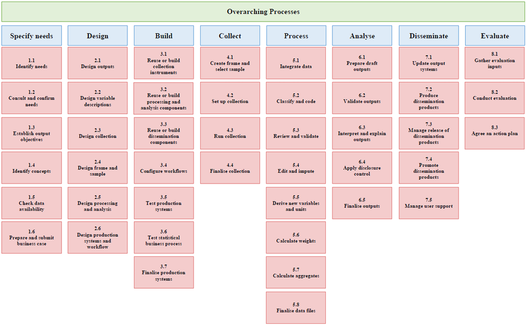

If we look at GSBPM — a model that describes the **full lifecycle of statistical production**, from identifying user needs to data dissemination — we can see that GIS tools and Python support many of its key phases.

In particular, the **Process** phase, where data are cleaned, integrated, and prepared for analysis. This is where this workshop is most strongly grounded. You will be working with spatial data and performing operations such as linking statistical data with geometry, spatial aggregation, and coordinate reference system transformations.

But this is not all. The same tools also support the **Analyse** phase. With a spatial approach, we are not only calculating indicators, but also understanding their variation in space: identifying concentrations of phenomena, analyzing accessibility of services, or exploring spatial relationships.

Finally, there is the **Disseminate** phase. Here, GIS plays a key role by enabling the presentation of data in the form of maps, which are often more intuitive and useful for users than traditional tables.

## Global Statistical Geospatial Framework

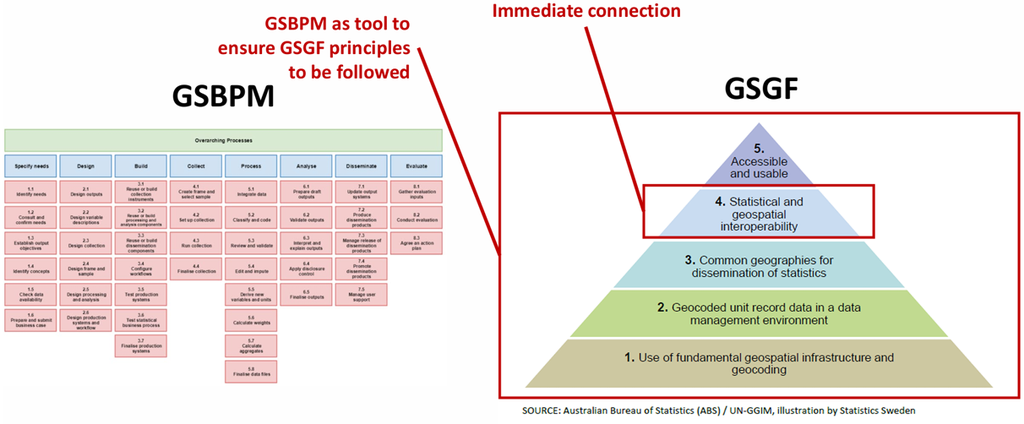

GSBPM vs GSGF

On the other hand, we have the **Global Statistical Geospatial Framework**, which addresses the question: how should we effectively integrate statistical and geospatial information?

One of its core principles is that statistical data should be linked to location. This is the foundation of this workshop. You will work with data that has a spatial reference — whether through address points or territorial units.

Another important element is **geocoding**, which means assigning data to specific locations. This process enables the transition from tabular data to spatial analysis.

A further principle is the **use of common geographies**, such as spatial grids or standardized administrative divisions. These allow data from different sources to be compared and integrated.

**Interoperability** is also essential - the ability of different datasets and systems to work together. This is where Python and QGIS demonstrate their strength: they allow us to integrate data from multiple sources and in various formats within a single analytical environment.

And finally, **accessibility and usability of data**. The ultimate goal is not just analysis, but delivering information in a form that provides value to users - very often as maps or geospatially enabled products.

Try to think of GIS not only as a visualization tool, but as a **way of thinking about data**.

Moving from tabular data to spatial data is not just a change in presentation. It is a shift in how we analyze information - because we begin to ask different questions and uncover relationships that were previously invisible.

Not only how to use specific tools, but also where they fit into the statistical process and why they are becoming increasingly important in modern official statistics.

# 3 GeoPandas - basics

[GeoPandas](https://geopandas.org) is a powerful Python library that makes working with geospatial data simple and efficient. It’s built on top of the popular `pandas` library, which is used for data manipulation and analysis in Python. `geopandas` adds support for spatial data and geometric operations. If you’re familiar with `pandas`, you will be able to work with geospatial datasets using familiar syntax and tools. If not, `geopandas` is very easy to learn.

GeoPandas works primarily with a specialized data structure called a **GeoDataFrame**. This is an extension of the standard `pandas` DataFrame that stores tabular data with rows and columns, but also includes a special `geometry` column that holds spatial shapes such as points, lines, or polygons. This `geometry` column enables spatial operations and geographic analyses directly on the dataset. When you read a geospatial dataset with GeoPandas, it is loaded into a GeoDataFrame.

## Launch QGIS

Launch the **QGIS Desktop** application on your computer and await further instructions.

## Open the Python Console

Before we use `geopandas` we need to make sure it is installed. We’ll do that in the QGIS Python console:

- In the QGIS main window, go to the top menu bar.
- Click on Plugins → Python Console.
- or you can press **Ctrl + Alt + P** (Windows/Linux) or **Cmd + Alt + P** (Mac) to open the Python Console.

## Install GeoPandas using `pip`

First, check if GeoPandas is installed. In the Python Console, type the following command and press Enter:

```python
try:
    import geopandas as gpd
    print("GeoPandas is installed.")
except ImportError:
    print("GeoPandas is not installed.")
```

If not, you can install GeoPandas using `pip`

### Note: What is `pip`?

> **`pip`** is the standard package manager for Python. It allows you to **install, upgrade, and manage Python libraries and packages** from the Python Package Index (PyPI) and other sources.

> With `pip`, you can:
> - **Install packages** – e.g. `geopandas`, `numpy`, etc., using a command like `!pip install geopandas`.
> - **Upgrade packages** – keep your libraries up to date.
> - **Uninstall packages** – remove packages you no longer need.
> - **Manage dependencies** – install the libraries that other packages require.

> QGIS uses its own Python environment, but you can still run `pip` commands from inside the Python Console.

In the console, enter the following command:

```python
!pip install geopandas
```

Just in case, verify if GeoPandas is installed, by typing the following code **one line at a time**:

```python
import geopandas as gpd
```

```python
print("GeoPandas version:", gpd.__version__)
```

## QGIS Python Editor

The Python Editor in QGIS lets you write and run Python scripts to automate tasks and work with geospatial data (using GeoPandas for example). It includes syntax highlighting and an interactive console, used by us already. When you execute scripts in the editor, the console will show you outputs, messages and errors. The editor allows you to save your scripts to disk. Remember to do it frequently to avoid losing your work.

We will read our first dataset using GeoPandas, but first a few words on… **how to start writing and running a Python script in QGIS:**

1. Go to the menu: **Plugins → Python Console** (or press `Ctrl+Alt+P`). This opens the Python Console.
2. In the Python Console, click the **Show Editor** button to open the Python Editor.
3. In the Python Editor, you can write your script. For example, you can paste the GeoPandas code, which follows.
4. Save your script with a `.py` extension using **File → Save As…** (for example, `read_nuts.py`).
5. To run the script, click the **Run Script** button (the green play icon) in the editor toolbar.
6. The output and any print statements will appear in the Python Console.

## Reading datasets with GeoPandas

Our adventure with GeoPandas will begin by reading a NUTS layer from Eurostat’s website. Before running the code below, please [**download the NUTS 2024 Shapefile in ZIP archive**](https://gisco-services.ec.europa.eu/distribution/v2/nuts/shp/NUTS_RG_20M_2024_3035_LEVL_0.shp.zip) and extract it into the folder `C:\GSGF_CARE_Python`.

Note that the file is part of the [Eurostat GISCO repository](https://gisco-services.ec.europa.eu/distribution/v2/nuts/shp/). More info (plus easy customization of the download) on the [Eurostat GISCO NUTS website](https://ec.europa.eu/eurostat/web/gisco/geodata/statistical-units/territorial-units-statistics).

Once the files are extracted, add the NUTS layer to the map and answer the following questions:

- Which NUTS level does the layer represent?
- What is the reference year?
- What is the reference scale of the data?
- What is the coordinate reference system?

Click to reveal the answers below:

**Answers**

- NUTS level 0 (country)
- Reference year 2024
- Reference scale 1 : 20 000 000 (20M)
- CRS 3035 (Lambert Azimuthal Equal Area)

Note: You can read all this from the file name :)

Now that you know a few things about the downloaded dataset, you can read the Shapefile with GeoPandas as follows. Paste the following code snippets to the Python Editor:

### Start with importing GeoPandas

```python
#import GeoPandas
import geopandas as gpd
```

GeoPandas is usually imported as `gpd`.

### Note: What is the purpose of lines starting with a hashtag?

> These are comments. Commenting your code **improves readability and reusability** - when you open the script after a longer period of time, you will be able to quickly learn the purpose of all commented code fragments and amend them to other purposes or reuse whole blocks.

> Commenting you code also: - **facilitates collaboration**: members of your team will quickly grasp the code’s functionality.  
> - **supports documentation**: if you ever need to document your script (e.g. as a part of a project report), a commented script can be attached to the documentation as is. The comments may also serve as a basis for summarizing the script in the report.

### Specify the path to the Shapefile

```python
#specify path to the extracted Shapefile
shp_path = r"C:\GSGF_CARE_Python\NUTS_RG_20M_2024_3035_LEVL_0.shp"
```

Here, a string variable `shp_path` is assigned the full path to a shapefile on your computer.  
The prefix `r` before the string marks it as a *raw string*, telling Python to treat backslashes (`\`) as literal characters and not as escape sequences (e.g., `\n` for newline).

### Note: Why store file paths in a variable?

> Storing file paths in a variable in Python has several advantages:
> - **readability**: It makes your code easier to read and understand. Instead of repeating a long file path multiple times, you define it once and refer to the variable.
> - **reusability**: You can use the same path in multiple places (e.g. for reading and writing) without duplication.
> - **easier maintenance**: If the path changes, you only need to update it in one place instead of searching through your code for every occurrence.
> - **error reduction**: Avoids typos or inconsistencies when using the same path in multiple places.

> In short, using a variable for paths leads to cleaner, safer, and more maintainable code — especially as your script grows or gets reused in different contexts.

### Read the Shapefile into a GeoDataFrame

```python
#read the Shapefile into a GeoDataFrame
gdf = gpd.read_file(shp_path)
```

This line uses GeoPandas’ `read_file` function to load the shapefile located at `shp_path` into a GeoDataFrame called `gdf`.

### Display first few rows

```python
#display the first few rows
print(gdf.head())
```

This prints the first few rows of the GeoDataFrame to the console, allowing you to just verify if the dataset was loaded correctly. The result is usually narrowed down to two or three columns, so you won’t be able to check the full structure of the data.

The result can look like that:

```
NUTS_ID                                            geometry
0      SI   POLYGON ((4786947.85 2658724.94, 4788640.346 2...
1      SK   POLYGON ((5019481.071 2968215.317, 5028815.352...
2      TR   MULTIPOLYGON (((6366766.004 2448944.963, 63694...
3      UA   MULTIPOLYGON (((5885782.205 3503801.659, 58987...
4      XK   POLYGON ((5254073.84 2267297.916, 5255677.894 ...

[5 rows x 9 columns]
```

Where is the data now (aside from the Shapefile on disk)?

**Answer**

The data was loaded to your computer’s memory, where it is accessible to Python commands.

## Introducing the GeoPackage

Before we move on, let’s talk about an open geospatial data format: the GeoPackage. It is an open, standards-based, platform-independent, and compact format for storing geospatial data. It uses the file extension `.gpkg`.

GeoPackage was developed by the Open Geospatial Consortium (OGC). It is designed to efficiently store vector and raster data with related attributes all in a single file using a lightweight SQLite database. GeoPackage supports complex spatial data types and is widely supported by many GIS software applications, making it an excellent choice for sharing and managing spatial data across different platforms without relying on proprietary formats.

## Shapefiles vs GeoPackages

While the Shapefile format is common and widely used, GeoPackage surfaces as an efficient and stable open alternative. Have a look at the comparison of the two formats:

| Feature | Shapefile | GeoPackage |
| --- | --- | --- |
| Maintained by | Esri | Open Geospatial Consortium (OGC) |
| Format Origin | Introduced in early 1990s | Released as OGC standard in 2014 |
| File structure | Multiple files (.shp, .shx, .dbf…) | Single-file SQLite-based container |
| Data types | Limited (no support for mixed types) | Supports advanced types & metadata |
| Attribute limits | 255 fields, 10 char field names | No such limits |
| Maximum dataset size | Typically up to 2 GB per file (due to 4GB file size limit and multiple files required) | Limited by SQLite size, generally up to 140 TB, effectively unlimited for most use cases |
| Performance | Slower for large datasets | Better performance with large data |

## Saving the dataset as a GeoPackage

To save the GeoDataFrame as a GeoPackage, use the following code:

```python
#specify path for the output GeoPackage
gpkg_path = r"C:\GSGF_CARE_Python\NUTS_RG_20M_2024.gpkg"
```

### Note

> Just like when reading a dataset, we stored the path in a variable.

```python
#write GeoDataFrame to GeoPackage
gdf.to_file(gpkg_path, driver="GPKG")
```

### Note

> When writing a GeoPackage, you need to specify the `driver=“GPKG”. The default driver is Shapefile, so when writing a Shapefile with GeoPandas, no driver specification is needed.

```python
print(f"GeoPackage saved to {gpkg_path}")
```

### Note

> The last line uses an **f-string** (formatted string literal) to print a message that includes the value of the variable `gpkg_path`.
> - **What is an f-string?**  
>   An f-string is a way to embed expressions inside string literals, using curly braces `{}`. It was introduced in Python 3.6 and provides a concise and readable way to format strings.
> - **How does it work here?**  
>   The string inside the quotation marks starts with `f`, signaling Python to evaluate any expression inside `{}`. In this case, `{gpkg_path}` is replaced with the actual value stored in the variable `gpkg_path` when the print statement runs.
> - **Advantages of using f-strings with variables of different types:**
>   - **readability:** It’s easier to write and understand the code.
>   - **type flexibility / maintenance:** You can embed variables of any data type (strings, numbers, objects with string representations, etc.) without needing to manually convert them. Python automatically converts the value inside `{}` to a string. Embedding variables directly in the string helps you avoid errors.
>   - **performance:** f-strings are generally faster than older methods like string concatenation or `str.format()`.

After executing the code, please check if the GeoPackage was saved correctly on disk.

# 4 Exploring a GeoDataFrame with GeoPandas

Once you loaded your spatial data into memory, you have various GeoPandas methods at your disposal to find out more about the data.

This part of the workshop will show you a few essential methods for inspecting the structure and spatial properties of a `GeoDataFrame`. You can paste them into your script in the Python editor.

Since our previous script included writing outputs, let’s start a new one, so we don’t have multiple outputs.

## Start a new script, import libraries and load data

You can start a new script in the QGIS Python Editor by using the green button.

**Please note**

Please note: We are now starting a **new script** in the QGIS Python Editor.  
We can **execute this script along the way** as we are operating in memory only.

Since it’s a new script, we have to start with importing libraries and reading data:

```python
import geopandas as gpd

#define the path to the GeoPackage file
gpkg_path = r"C:\GSGF_CARE_Python\NUTS_RG_20M_2024.gpkg"

#define the layer name inside the GeoPackage
nutsLayer = "NUTS_RG_20M_2024"

#load the NUTS layer into a GeoDataFrame.
gdf = gpd.read_file(gpkg_path, layer=nutsLayer)
```

Let’s go on to explore some methods for exploring GeoDataFrames.

## List column names

This method allows you to Lists all column names in the GeoDataFrame.

```python
#print all column names
print(gdf.columns)
```

Expected result:

```
Index(['NUTS_ID', 'LEVL_CODE', 'CNTR_CODE', 'NAME_LATN', 'NUTS_NAME',
       'MOUNT_TYPE', 'URBN_TYPE', 'COAST_TYPE', 'geometry'],
      dtype='object')
```

## Inspect and adjust data types of columns

This method will give you a little bit more information, showing the data type (dtype) of each column, including geometry and attribute fields.

```python
#display data types for each column
print(gdf.dtypes)
```

Expected result:

```
NUTS_ID         object
LEVL_CODE        int32
CNTR_CODE       object
NAME_LATN       object
NUTS_NAME       object
MOUNT_TYPE     float64
URBN_TYPE      float64
COAST_TYPE     float64
geometry      geometry
dtype: object
```

### Why are strings an “object” dtype in GeoPandas?

> In **Pandas** (and thus GeoPandas), **string columns are stored with the data type `"object"`** because:
> - Historically, Pandas didn’t have a dedicated string data type.
> - The `"object"` dtype is a **generic container for any Python objects**, so it’s used to store text strings as Python `str` objects.
> - This allows columns to hold mixed types if needed (though usually they’re all strings in a text column).
> - Recently, Pandas introduced a dedicated `"string"` dtype (using `pd.StringDtype()`), but `"object"` is still very common and widely used for strings.

> You can convert an `"object"` column holding strings into the new `"string"` dtype like this:

> ```python
> gdf['name'] = gdf['name'].astype('string')
> ```

> In this line of code, you need to substitute ‘name’ with the actual name of the column in your GeoDataFrame.

> The conversion can improve memory usage and enable some string-specific methods.

Let’s convert all the “object” dtypes to “string”:

```python
#convert all columns with dtype 'object' to pandas 'string' dtype
for col in gdf.columns:
    if gdf[col].dtype == 'object':
        gdf[col] = gdf[col].astype('string')

#check the updated dtypes
print(gdf.dtypes)
```

### What happened here? Iteration (loop), checking condition and automation

> Since this is the first more complicated piece of code, let’s analyze what happened step by step
> - `gdf.columns` is a special pandas object called an **Index**. It behaves like a Python `list` in many ways, which means you can **iterate over it using a `for` loop**. This lets you easily access each column name one at a time without needing to specify columns names.
> - The **`for` loop** goes through each column name in the GeoDataFrame (`gdf.columns`) one by one.
> - The **`if` statement** checks whether the current column’s data type is `'object'`, which usually means it stores text strings.
> - If the condition is true, it converts that column’s data type from `'object'` to the newer `'string'` type.

> This way, the code **automatically processes only the relevant columns**, without needing to list them manually. This is a simple example of automating repetitive tasks in programming using loops and conditions.

> Automation of data processing - this is where true power of Python lies. More examples will follow!

## Check the coordinate reference system (CRS)

Returns the **Coordinate Reference System** (CRS) of the GeoDataFrame as an EPSG Code.

### What is an EPSG Code?

> An **EPSG code** is a unique identifier assigned to a specific **Coordinate Reference System (CRS)** formerly managed by the *European Petroleum Survey Group*.

> For example, `EPSG:4326` refers to the commonly used **WGS 84 geographic coordinate system**, which represents locations using latitude and longitude.

> Another widely used CRS is `EPSG:3857`, also known as **Web Mercator**. It is a **projected coordinate system** that represents positions in meters and is used by most web mapping platforms (like Google Maps and OpenStreetMap). While it’s great for visualization, it distorts areas—especially near the poles.

> Another well known CRS is `EPSG:3035` - the **Lambert Azimuthal Equal Area** projection used to disseminate Europe-wide grid datasets, like population grids from the series of GEOSTAT project or census results reporting from the 2021 population census.

> EPSG codes are widely used in GIS software (like GeoPandas, QGIS, PostGIS) to define how spatial data should be interpreted, projected, and displayed on a map.

> Using the correct EPSG code ensures that spatial data aligns properly across datasets and tools.

> For more info visit the [EPSG website](https://epsg.org/)

```python
#print the coordinate reference system of your dataset
print(gdf.crs)
```

Expected result:

```
EPSG:3035
```

## Reprojecting a GeoDataFrame

Reprojecting spatial data to a new coordinate reference system (CRS) is a common task in GIS. In just one line of code, you can convert your data to any CRS you need, enabling seamless integration, analysis, and visualization with other datasets.

```python
#reproject to EPSG:4326 (WGS84 Latitude/Longitude)
gdf_reprojected = gdf.to_crs(epsg=4326)

#verify the new CRS
print(gdf_reprojected.crs)
```

### Note

> The `to_crs()` method returns a **new** GeoDataFrame with the geometries reprojected. Your original `gdf` remains unchanged unless you overwrite it.

## Get the spatial extent of the dataset

With a simple line of code you can retrieve the spatial extent of the entire dataset as `(minx, miny, maxx, maxy)`.

```python
#print the bounding box of the dataset
print(gdf.total_bounds)
```

Expected result:

```
[-2824090.7973 -3076483.3894 10024822.6966  6410739.4567]
```

## Check geometry types of your data

Another simple line of code will show you what geometry types (e.g., `Polygon`, `Point`, `LineString`) are in your GeoDataFrame and how many features are of each type.

```python
#print counts of each geometry type
print(gdf.geom_type.value_counts())
```

How many geometry types do you expect to see in the NUTS dataset?

Click to reveal the answer below:

**Answer**

[output not shown]

# 5 Use case #1 intro: Assign the European grid identifier to point data - the source dataset

## Integrating the GRID_ID in the statistical production process

Reporting survey results to Eurostat in **grids** is slowly becoming the new norm, and rightfully so. What you can do in your organization to streamline this process is to assign the grid ID to survey frames.

### Note: Structure of the European grid cell code

> An example of a grid cell code: `PL_CRS3035RES1000mN3057000E5131000` consists of the following:
> - **`PL`**: Country code based on the ISO standard (here, Poland), identifying the national territory to which the grid cell belongs.
> - **`CRS3035`**: Unique identifier of the adopted coordinate reference system, i.e. ETRS89-LAEA (EPSG:3035).
> - **`RES1000m`**: Grid cell resolution, indicating a cell size of 1000 meters.
> - **`N[y]`**: Northing value, where *y* represents the coordinate (in meters) of the lower-left corner of the grid cell.
> - **`E[x]`**: Easting value, where *x* represents the coordinate (in meters) of the lower-left corner of the grid cell.

The most popular survey, which is reported in grids is of course the populaton census. Census data is collected for persons and dwellings. The optimal approach to collect (and then disseminate) data is to assign them to points, so they can later be aggregated to grids (or any other territorial division).

In Statistics Poland we base the census on the **Social Survey Frame**, which holds unit data on persons and dwellings. We also maintain the Spatial Address Database (PBA) as part of our territorial register (TERYT). **Statistical address points** - locations of buildings with at lease one dwelling - are a part of this database. So to facilitate aggregation to grids, we assigned the `GRID_ID` to every statistical address point. Then we matched all statistical units in the Social Survey Frame, so the `GRID_ID` could be propagated to all statistical units in the survey frame, like **persons** or **dwellings**.

We ensured the `GRID_ID` was attached to all census data from the very start, that’s why we could easily aggregate census results for dissemination purposes.

Making the `GRID_ID` and integral part of the survey frame facilitates efficient dissemination of statistics and greatly reduces time needed for post-processing survey results.

The `GRID_ID` can be integrated into any other survey frame just as easily, to facilitate dissemination of results of surveys other that the census, e.g. Integrated Farm Statistics (formerly known as Farm Structure Survey).

## Assigning the GRID_ID to point data using Python – outline

For the first use case we’ll guide you through building a script that will assign the `ETRS89-LAEA European GRID ID` to any type of point data. First, we’ll need some data to work with. Each of you will generate a point cloud inside your country and then we’ll assign the GRID_ID to those points.

The work plan:

- **script #1: generating a point cloud inside your country**: this part will show you an easy way to use the geometry of the NUTS layer as a boundary for randomly generated points
- **script #2: assigning the GRID_ID to point data**: this part will show you how easy it is to write code for GRID_ID calculation

# 6 Use case #1 part 1: Create the source dataset

## Start a new script, import libraries and load data

We’ll kick off with staring a new script for generating the point cloud.

You can start a new script in the QGIS Python Editor by using the green button.

**Please note**

We are now starting a **new script** in the QGIS Python Editor.  
We will **execute this script when it’s complete** to avoid duplicate outputs along the way.

Since it’s a new script, we have to start with importing libraries and reading data:

```python
import geopandas as gpd

#define the path to the GeoPackage file
gpkg_path = r"C:\GSGF_CARE_Python\NUTS_RG_20M_2024.gpkg"

#define the layer name inside the GeoPackage
nutsLayer = "NUTS_RG_20M_2024"

#load the NUTS layer into a GeoDataFrame.
gdf = gpd.read_file(gpkg_path, layer=nutsLayer)
```

## Define variables

We’ll define variables to be used in the script at the start. First for country code. Defining variables at the beginning of the script makes it easy for re-use in the future.

### Note

> Even short strings (like the country code) should be stored as Python variables rather than hard-coded directly in the script. This improves **maintainability** and **reusability**: values defined once can be easily located, updated, and reused across multiple steps without searching through the entire codebase.

Create a variable with your own country code. If you’re not sure what the code for your country is, have a look at the attribute table of the NUTS layer.

```python
#define the country code
countryCode = 'PL'
```

Now we need to decide how many points we want to generate. This we will also store in a variable, so it can be easily changed later.

```python
#define the number of random points
numberOfPoints = 1000000
```

And finally, let’s create a variable for the resulting point layer name.

```python
#define the resulting point layer name
pointLayer = 'survey_points'
```

## Select the country geometry

To generate a point cloud inside the country, we need to load the country geometry to memory. For that we’ll select a part of the NUTS `GeoDataFrame` based on the `CNTR_CODE` attribute:

```python
#select the country geometry
gdfCountry = gdf[gdf['CNTR_CODE']==countryCode]
```

### Note

> This line of code performs a **subsetting (filtering) operation** on a GeoDataFrame:

> `gdfCountry = gdf[gdf['CNTR_CODE'] == countryCode]`

> Specifically, it selects only those rows (geometries) from `gdf` where the value in the `CNTR_CODE` column matches the value stored in the `countryCode` variable. The result is a new GeoDataFrame (`gdfCountry`) containing only the features for the chosen country.

> This selection syntax comes from the **boolean indexing mechanism** in `pandas`, which is fully supported by GeoDataFrames in the `geopandas` library. Since a GeoDataFrame is essentially an extension of a pandas DataFrame with a geometry column, most data manipulation operations—such as filtering, grouping, or joining—follow the same logic and conventions as in `pandas`.

> In practice, this approach is widely used in geospatial workflows to isolate subsets of spatial data based on attribute values before performing further analysis or processing.

We’ll keep the country geometry in memory only for further processing.

## Generate a random point cloud within the country boundary

To generate random points, we’ll use the `geopandas.sample_points` method. It will generate one multipoint with a number of geometries equal to the `size` parameter value. What we’re used to work with is points as separate features, so we’ll need to split this multipoint into individual points using `geopandas.explode`.

First, we need to retrieve the selected country geometry:

```python
#retrieve the country geometry from the GeoDataFrame
sampleArea = gdfCountry.geometry
```

Next, we’ll generate random points (as one multipoint) using `geopandas.sample_points`:

```python
#generate random points
randomMultiPoint = sampleArea.sample_points(size=numberOfPoints)
```

To acquire individual points as separate features, we’ll use `geopandas.explode` on our last result:

```python
#split the multipoint into individual points
randomPoints = randomMultiPoint.explode(ignore_index=True)
```

The `ignore_index` parameter allows us to forfeit the original index of the multipoint. If you use the `geopandas.explode` method on another layer, where you want to preserve the origin of the split geometries, use `index_parts=True` instead.

## Write the result to our GeoPackage

```python
#write the point layer to our GeoPackage
randomPoints.to_file(gpkg_path, driver='GPKG', layer=pointLayer)

print("Random points layer saved successfully.")
```

We’ve created a dataset mimicking a point based survey frame. We’ll treat is as locations of dwellings, farms or other statistical units for the purpose of assigning the `GRID_ID` to each point.

# 7 Use case #1 part 2: Calculate and write the GRID_ID

## Start a new script, import libraries and load data

You can start a new script in the QGIS Python Editor by using the green button.

**Please note**

We are now starting a **new script** in the QGIS Python Editor.  
We will **execute this script when it’s complete** to avoid duplicate outputs along the way.

Since it’s a new script, we have to start with importing libraries and reading data:

```python
import geopandas as gpd
import datetime

#define the path to the GeoPackage file
gpkg_path = r"C:\GSGF_CARE_Python\NUTS_RG_20M_2024.gpkg"

#define the point layer name inside the GeoPackage
pointLayer = "survey_points"

#load the point layer into a GeoDataFrame.
gdf = gpd.read_file(gpkg_path, layer=pointLayer)
```

### Note: the `datetime` module

> Notice that aside from `geopandas` we imported another module: `datetime`. With this module we can capture dates and times, but also measure time. We’ll use this module to measure how long the script does its job and how much time we are saving by scripting the process instead of doing it step by step manually.

Let’s capture the time signature for the start of the script.

```python
#capture the time signature for the start of the script
start = datetime.datetime.now()
```

We’ll come back to `datetime` at the end of the script.

## Define variables

Just like before, we’ll define variables to be used in the script at the start. We’ll need the country code again but also the grid cell size. The usual grid resolution for reporting is 1 km, but we want our script to be reusable for different resolutions. That’s why we’re setting the cell size as a parameter (variable).

Define your country code as a variable and the cell size of 1000:

```python
#define the country code
countryCode = 'PL'

#define the cell size
cellsize = 1000
```

We’ll also need a layer name for the output:

```python
#define the output layer name
outputLayer = "survey_points_grid"
```

## Reproject the point layer to ETRS89-LAEA

Our dataset is already in ETRS89-LAEA - `EPSG:3035`. But if you use the script on your local country dataset, it most probably will have a local projection. Therefore you will need to reproject it using `geopandas.to_crs`, like we did here.

We can add the code for reprojection just in case. It won’t change anything if the `GeoDataFrame` is already in the CRS used in the reprojection.

```python
#reproject to EPSG:3035 (Lambert Azimuthal Equal Area)
outputDS = gdf.to_crs(epsg=3035)
```

## Calculate the GRID_ID

We will proceed to calculate the GRID_ID for the whole dataset, by:

- retrieving the x and y coordinates from the dataset,
- calculating the grid cell coordinates,
- constructing the GRID_ID.

We’ll start with retrieving the coordinates as columns in the `GeoDataFrame`:

```python
#X_LAEA: X coordinate (easting) in the projected CRS
#Y_LAEA: Y coordinate (northing) in the projected CRS
outputDS['X_LAEA'] = outputDS.geometry.x
outputDS['Y_LAEA'] = outputDS.geometry.y
```

Then we’ll calculate the grid cell coordinates (lower left corner of the grid cell):

```python
#Snap points to the grid
#Each coordinate is adjusted to the lower-left corner of its grid cell
#The modulo operation (%) finds the remainder, which is subtracted to align to the grid
outputDS['X_GRID'] = (outputDS['X_LAEA'] - outputDS['X_LAEA'] % cellsize).astype(int)
outputDS['Y_GRID'] = (outputDS['Y_LAEA'] - outputDS['Y_LAEA'] % cellsize).astype(int)
```

### Note

> Snapping the survey points to grids was done without any geospatial processing. This was just a mathematical operation done on the `GeoDataFrame`. Calculations instead of geospatial operations greatly decrease processing time!

Finally, we’ll construct the GRID_ID according to the structure described here.

```python
#construct a unique GRID_ID for each point
outputDS['GRID_ID'] = (
    countryCode + "_CRS3035RES" + str(cellsize) + "mN" +
    outputDS['Y_GRID'].astype(str) + "E" +
    outputDS['X_GRID'].astype(str)
    )
```

Have a look at the following figure to see a graphic summary of the process:

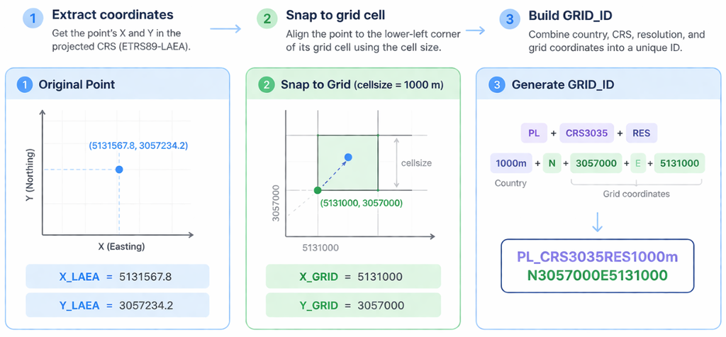

Assigning the GRID_ID

## Save the result to the GeoPackage

To save the GeoDataFrame as a GeoPackage, use the following code:

```python
#writing the point layer to our GeoPackage
outputDS.to_file(gpkg_path, driver='GPKG', layer=outputLayer)

print("Points with GRID_ID saved successfully.")
```

## Measure the script execution time

Let’s come back to the `datetime` module we used at the beginning of the script. We’ll capture the end time and then calculate the difference to see what was the execution time.

```python
#capture the time signature of the end of the script
end = datetime.datetime.now()

#create a variable to store script execution time
dur = datetime.timedelta()

#calculate execution time
dur = end - start

print("Points with GRID_ID saved successfully in ([H]H:MM:SS[.UUUUUU])" + str(dur) +".")
```

- How long was the script working on your workstation?
- How many address points do you have in your country?
- Is it feasible to use a script to assign GRID_ID instead of doing it manually each time we need to update the survey frame?

# 8 Use case #2: Calculate the number of addresses that could be affected by floods for different predictions

The second use case of this workshop will utilize a simple spatial analysis and show you how to design and run repeatable operations in Python.

## Download and Explore the Data

Data for this usecase is in a GeoPackage available to download from the [EFGS website](https://www.efgs.info/wp-content/uploads/2026/04/flood_data.zip). Please download it and move it to the `C:\GSGF_CARE_Python` folder on your laptop.

Have a look at the GeoPackage content in the QGIS Browser:

flood_data.gpkg  
├── adr  
├── flood_0_2  
├── flood_1  
└── flood_10

Add the content of the GeoPackage to QGIS layers.

The GeoPackage contains an address layer and three flood predictions:

- area with a 10% river flood risk (once in 10 years)
- area with a 1% river flood risk (once in 100 years)
- area with a 0,2% river flood risk (once in 500 years)

Define layer symbolization in QGIS, e.g. change layer color to different shades of blue, optionally turn of stroke (Layer Styling panel -> Simple Fill properties -> Stroke style -> No Line).

During this exercise we’ll calculate how many addresses can be affected by the three flood predictions.

The area of interest is Nysa (Kłodzka) river basin in Poland - the location of 2024 floods.

For background information, please add the **OpenStreetMap** tiles (XYZ tiles -> OpenStreetMap) to QGIS layers, move the tiles to the bottom of the layer list.

The QGIS window can look like this:

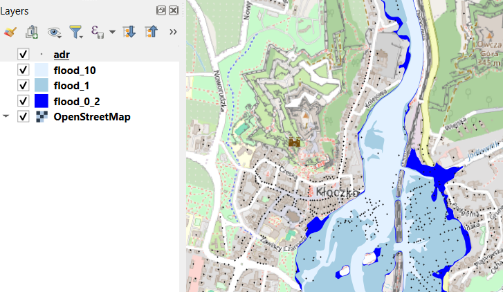

QGIS Window View

## Start a new script, import libraries and load data

We’ll begin the exercise by staring a new script in the QGIS Python Editor by using the green button.

**Please note**

We are now starting a **new script** in the QGIS Python Editor.  
We can execute this script while we go, byt we will **execute it when it’s complete**, because outputs will appear at the end.

Since it’s a new script, we have to start with importing libraries and reading data:

```python
import geopandas as gpd

#define the path to the GeoPackage file
gpkg_path = r"C:\GSGF_CARE_Python\flood_data.gpkg"

#define the address point layer name inside the GeoPackage
addressLayerName = "adr"

#load the addresses point layer into a GeoDataFrame.
addressLayer = gpd.read_file(gpkg_path, layer=addressLayerName)
```

## Create a list of flood risk layers

In this step, we define a list that contains the names of flood risk layers we have in our GeoPackage:

```python
#provide a list of flood risk layer names
floodLayers = ["flood_10", "flood_1", "flood_0_2"]
```

### Note: What are lists?

> In Python, a list is an ordered, mutable collection of elements. It allows you to store multiple values - such as strings, numbers, or objects — in a single variable, and then access or manipulate them using Python commands. Lists are especially useful when you need to apply the same operation to many items, because they can be iterated over using loops.

Here, `floodLayers` is a Python list composed of three string elements. Each string corresponds to a flood risk layer name (as specified above).

This list will be used later in the script to iterate through the flood risk layers. By looping over `floodLayers`, we can automate repetitive geospatial processing tasks — such as loading data, performing spatial analysis and calculating results — without writing separate code for each layer. This approach improves both efficiency and maintainability of the workflow.

Python is all about reusability: once we finish you can use the script in a different way, e.g.:

- define a different list of flood risk layers
- add new flood risk layers
- define a different input layer (e.g. buildings instead of points)

and you will get similar results without the need to redefine the spatial analysis part.

## Iterate through flood risk layers and count affected addresses

As promised, in this step, we automate the analysis by looping through each flood risk layer defined earlier and performing the same spatial operation on those layers. This pattern — iterating through lists — is fundamental in Python and allows us to scale workflows efficiently without duplicating code.

```python
#iterate through the flood risk layers to count the address points
for floodLayerName in floodLayers:
    #load the flood risk layer into a GeoDataFrame.
    floodLayer = gpd.read_file(gpkg_path, layer=floodLayerName)
    #create a spatial join of the address layer and flood risk layer
    affectedLayer = gpd.sjoin(addressLayer, floodLayer, predicate="intersects")
    #count the number of affected addresses
    affectedAddresses = len(affectedLayer)
    #print out the result
    print(f"Number of addresses affected in flood prediction {floodLayerName}: {affectedAddresses}")
```

The `for` loop iterates over each element in the `floodLayers` list, assigning the current layer name to the variable `floodLayerName`. For each iteration, the corresponding flood layer is loaded from a GeoPackage into a GeoDataFrame using `gpd.read_file()`.

Next, a spatial join (`gpd.sjoin`) is performed between the address dataset and the flood risk layer. The `"intersects"` predicate ensures that any address point falling within (or touching) a flood polygon is included in the result. This produces a new GeoDataFrame (`affectedLayer`) containing only the addresses exposed to that specific flood scenario.

We then compute the number of affected addresses using `len(affectedLayer)`, which returns the row count of the resulting dataset. Finally, the result is printed in a formatted string, clearly associating the number of impacted addresses with the corresponding flood layer:

```
Number of addresses affected in flood prediction flood_10: 417
Number of addresses affected in flood prediction flood_1: 2718
Number of addresses affected in flood prediction flood_0_2: 5527
```

This script allowed us to quickly perform the same spatial analysis using three different input geometries. We were interested in the number of affected addresses and we received the numbers in the Python console. Note that the temporary outputs (like results of the spatial join) were not stored anywhere. So, instead of manually performing the spatial join three times and analyzing (plus possibly storing) the results, we just retrieved three numbers. On top of that, we have a reusable script for a similar workflow in the future.